[figure not shown]

# Uso de IA no setor de seguros

## Gabriel Gonçalves, Cientista de Dados | Desenvolvedor

## Redes Neurais e Machine Learning

- Redes Neurais são o motor de grandes modelos de IA, ensinam computadores a processar dados de forma inspirada no cérebro humano. Elas utilizam nós interconectados, chamados de "neurônios", organizados em camadas, que simulam a estrutura biológica do cérebro para reconhecer padrões, tomar decisões e aprender com erros.
- Chamamos de IA grandes modelos como: ChatGPT, Claude, Gemini, mas um nome mais preciso seria LLM (sigla em inglês para Modelos Linguisticos de Larga escala).
- Essas LLMs são compostas por redes neurais capazes de processar quantidades enormes de dados e entender tarefas enviadas via prompt de texto, imagem ou audio.
- Redes Neurais são usadas pela grande maioria das empresas em diversos setores para tarefas diversas como: Detecção de fraudes, reconhecimento facial, contagem de objetos em um video, sistemas de recomendações (youtube, spotify, netflix).

## Use Cases no setor de seguros

Usos de redes neurais e Machine Learning:

- Vistoria de veiculos automatizada
- Previsão de Sinistros com Machine Learning
- Marketing - identificação das melhores oportunidades de conversão
- Subscrição - classificação e seleção de riscos
- Detecção de fraudes

### Cases de sucesso em empresas do setor de seguros

1. Zego

> A Zego é uma empresa Data Driven que entendeu o valor dos dados que tinham e implementou no núcleo do négocio, hoje (segundo o [cientista de dados da zego, Rui Lopes](https://medium.com/zegocover/zegos-data-journey-first-get-the-data-fb6c9d782b17)) a empresa processa cerca de 1.3 milhões de dados por dia.

> A Zego utiliza IA avançada para personalizar seguros, avaliando riscos com precisão e oferecendo preços competitivos. Seus algoritmos também ajudam a prevenir fraudes (Como faremos mais a frente da apresentação), enquanto chatbots garantem atendimento rápido, aumentando a satisfação dos clientes e reduzindo custos.
2. Lemonade

> A Lemonade é uma seguradora que usa inteligência artificial e aprendizado de máquina para transformar o setor. Sua plataforma automatiza processos, reduz burocracia e elimina intermediários, tornando a contratação e o atendimento mais rápidos e eficientes. A IA é a principal inovação da empresa, permitindo oferecer uma experiência simples, digital e centrada no cliente, além de facilitar sua expansão para novos mercados e produtos. A Lemonade utiliza chatbots para substituir um formulário de sinistros, assim o processo parece rápido e personalizado.
3. Next Insurance

> A Next Insurance aposta em automação e IA para simplificar seguros voltados a pequenas empresas. A tecnologia reduz a necessidade de intervenção humana na maioria dos casos, acelerando a análise de riscos, emissão de apólices e atendimento, com foco em processos mais rápidos e escaláveis.

## Como funcionam?

[figure not shown]

- Busca os dados nas tabelas necessárias.
- Realiza preprocessamentos dos dados, processa(aplica filtros, texturizações e tenta entender padrões).
- Extrai caracteristicas dos dados.
- Treina com base nas caracteristicas extraidas e devolve uma saída (ex: é fraude? 0 ou 1) e treina com base na recompensa ou penalidade, se acertou ou errou.
- Avalia a performance do modelo baseado em métricas (precisão, acurácia, recall).

### Texturização e outras técnicas para retirada de informações dos dados

Para compreender uma imagem, a rede neural lê os pixels dela linha por linha, realiza processamentos nela como: texturização da imagem, filtros preto e branco, filtros de profundidade e segmentações.

[figure not shown]

Em Aprendizado de Maquina tradicional a imagem bruta é processada de inumeras formas porém ela não consegue aprender todos os detalhes que uma rede neural consegue. Aprendizado de máquina tradicional faz a extração de caracteristicas e a classificação separadamente para entender os padrões dos dados. A rede neural realiza isso sozinha com as camadas de neuronios.

[figure not shown]

## Exemplo técnico

- Produto: Detecção de fraude de seguro automotivo com dataset espanhol
- A ideia é detectar possiveis fraudes com base nos nossos dados da apolice, veiculo, segurado e sinistro.

**Colunas do dataset:**

- 'Month' - **(Mês)**
- 'WeekOfMonth' - **(Semana do mês)**
- 'DayOfWeek' - **(Dia da semana)**
- 'Make' - **(Marca do veiculo)**
- 'AccidentArea' - **(Área do acidente)**
- 'DayOfWeekClaimed' - **(Dia da semana em que foi comunicado o sinistro)**
- 'MonthClaimed' - **(Mês em que foi comunicado o sinistro)**
- 'WeekOfMonthClaimed' - **(Semana do mes em que foi comunicado o sinistro)**
- 'Sex' - **(Sexo)**
- 'MaritalStatus' - **(Estado civil)**
- 'Age' - **(Idade)**
- 'Fault' - **(A culpa é do condutor?)**
- 'VehicleCategory' - **(Categoria do veiculo)**
- 'VehiclePrice' - **(Preço do veiculo)**
- 'FraudFound_P' - **(Ocorreu uma fraude?)**
- 'RepNumber' - **(Id do corretor)**
- 'Deductible' - **(Custo do seguro)**
- 'DriverRating' - **(Classificação do condutor)**
- 'Days_Policy_Accident' - **(Contagem de dias entre o inicio da vigencia e o acidente)**
- 'Days_Policy_Claim' - **(Contagem de dias entre o inicio da vigencia e o aviso do sinistro)**
- 'PastNumberOfClaims' - **(Numero de sinistros passados)**
- 'AgeOfVehicle' - **(Tempo do condutor com o veiculo)**
- 'AgeOfPolicyHolder' - **(Idade do responsavel pela apolice)**
- 'PoliceReportFiled' - **(Houve B.O?)**
- 'WitnessPresent' - **(Testemunha está presente?)**
- 'AgentType' - **(A fraude ocorreu internamente - fraude via pessoa interna ou externamente - fraude via pessoa externa)**
- 'NumberOfSuppliments' - **(Quantidade de danos relatados)**
- 'AddressChange_Claim' - **(O segurado se mudou depois de relatar o acidente? - quanto tempo tem?)**
- 'NumberOfCars' - **(Quantidade de veiculos envolvidos no acidente)**
- 'Year' - **(Ano do veiculo)**
- 'BasePolicy' - **(Tipo de seguro)**

|  | Month | WeekOfMonth | DayOfWeek | Make | AccidentArea | DayOfWeekClaimed | MonthClaimed | WeekOfMonthClaimed | Sex | MaritalStatus | ... | AgeOfVehicle | AgeOfPolicyHolder | PoliceReportFiled | WitnessPresent | AgentType | NumberOfSuppliments | AddressChange_Claim | NumberOfCars | Year | BasePolicy |
| --- | --- | --- | --- | --- | --- | --- | --- | --- | --- | --- | --- | --- | --- | --- | --- | --- | --- | --- | --- | --- | --- |
| 0 | Dec | 5 | Wednesday | Honda | Urban | Tuesday | Jan | 1 | Female | Single | ... | 3 years | 26 to 30 | No | No | External | none | 1 year | 3 to 4 | 1994 | Liability |
| 1 | Jan | 3 | Wednesday | Honda | Urban | Monday | Jan | 4 | Male | Single | ... | 6 years | 31 to 35 | Yes | No | External | none | no change | 1 vehicle | 1994 | Collision |
| 2 | Oct | 5 | Friday | Honda | Urban | Thursday | Nov | 2 | Male | Married | ... | 7 years | 41 to 50 | No | No | External | none | no change | 1 vehicle | 1994 | Collision |
| 3 | Jun | 2 | Saturday | Toyota | Rural | Friday | Jul | 1 | Male | Married | ... | more than 7 | 51 to 65 | Yes | No | External | more than 5 | no change | 1 vehicle | 1994 | Liability |
| 4 | Jan | 5 | Monday | Honda | Urban | Tuesday | Feb | 2 | Female | Single | ... | 5 years | 31 to 35 | No | No | External | none | no change | 1 vehicle | 1994 | Collision |
| ... | ... | ... | ... | ... | ... | ... | ... | ... | ... | ... | ... | ... | ... | ... | ... | ... | ... | ... | ... | ... | ... |
| 15415 | Nov | 4 | Friday | Toyota | Urban | Tuesday | Nov | 5 | Male | Married | ... | 6 years | 31 to 35 | No | No | External | none | no change | 1 vehicle | 1996 | Collision |
| 15416 | Nov | 5 | Thursday | Pontiac | Urban | Friday | Dec | 1 | Male | Married | ... | 6 years | 31 to 35 | No | No | External | more than 5 | no change | 3 to 4 | 1996 | Liability |
| 15417 | Nov | 5 | Thursday | Toyota | Rural | Friday | Dec | 1 | Male | Single | ... | 5 years | 26 to 30 | No | No | External | 1 to 2 | no change | 1 vehicle | 1996 | Collision |
| 15418 | Dec | 1 | Monday | Toyota | Urban | Thursday | Dec | 2 | Female | Married | ... | 2 years | 31 to 35 | No | No | External | more than 5 | no change | 1 vehicle | 1996 | All Perils |
| 15419 | Dec | 2 | Wednesday | Toyota | Urban | Thursday | Dec | 3 | Male | Single | ... | 5 years | 26 to 30 | No | No | External | 1 to 2 | no change | 1 vehicle | 1996 | Collision |

15420 rows × 33 columns

```
FraudFound_P
0    14497
1      923
Name: count, dtype: int64
```

|  | Month | WeekOfMonth | DayOfWeek | Make | AccidentArea | DayOfWeekClaimed | MonthClaimed | WeekOfMonthClaimed | Sex | MaritalStatus | ... | AgeOfVehicle | AgeOfPolicyHolder | PoliceReportFiled | WitnessPresent | AgentType | NumberOfSuppliments | AddressChange_Claim | NumberOfCars | Year | BasePolicy |
| --- | --- | --- | --- | --- | --- | --- | --- | --- | --- | --- | --- | --- | --- | --- | --- | --- | --- | --- | --- | --- | --- |
| 0 | 2 | 5 | 6 | 6 | 1 | 5 | 4 | 1 | 0 | 2 | ... | 1 | 2 | 0 | 0 | 0 | 3 | 0 | 2 | 1994 | 2 |
| 1 | 4 | 3 | 6 | 6 | 1 | 1 | 4 | 4 | 1 | 2 | ... | 4 | 3 | 1 | 0 | 0 | 3 | 3 | 0 | 1994 | 1 |
| 2 | 10 | 5 | 0 | 6 | 1 | 4 | 9 | 2 | 1 | 1 | ... | 5 | 5 | 0 | 0 | 0 | 3 | 3 | 0 | 1994 | 1 |
| 3 | 6 | 2 | 2 | 17 | 0 | 0 | 5 | 1 | 1 | 1 | ... | 6 | 6 | 1 | 0 | 0 | 2 | 3 | 0 | 1994 | 2 |
| 4 | 4 | 5 | 1 | 6 | 1 | 5 | 3 | 2 | 0 | 2 | ... | 3 | 3 | 0 | 0 | 0 | 3 | 3 | 0 | 1994 | 1 |

5 rows × 31 columns

Aqui conseguimos ver o nível de correlação das colunas na tabela. É assim que a IA irá aprender as relações entre as variáveis e entender padrões entre o que é fraude e o que é um valor normal.

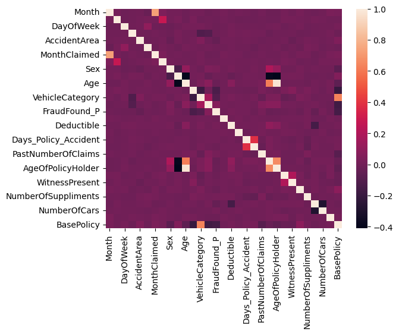

```
Quantidade de classes no treino:
FraudFound_P
0    9946
1     624
Name: count, dtype: int64,

Quantidade de classes no teste:
FraudFound_P
0    4262
1     268
Name: count, dtype: int64
```

## Rede Neural

[figure not shown]

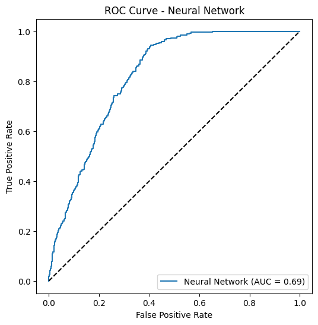

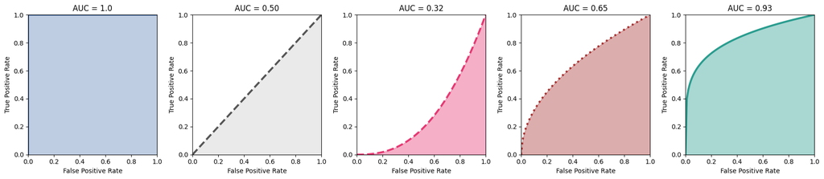

A curva ROC é construída calculando-se a taxa de verdadeiros positivos (TVP) e a taxa de falsos positivos (TFP) em cada limiar possível (na prática, em intervalos selecionados) e, em seguida, plotando-se o gráfico da TVP em função da TFP. Um modelo perfeito, que em determinado limiar apresenta uma TVP de 1,0 e uma TFP de 0,0, pode ser representado por um ponto em (0, 1).

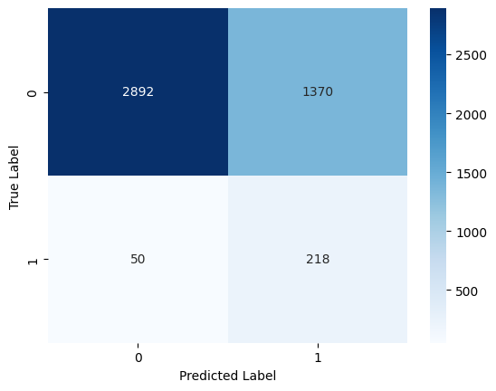

*Os modelos de aprendizado de máquina não podem ser 100% corretos porque são sistemas estatísticos projetados para identificar padrões, e não sistemas determinísticos que seguem regras fixas. Eles são essencialmente aproximações matemáticas da realidade, projetadas para generalizar a partir de dados limitados para o mundo real mais amplo, caótico e frequentemente imprevisível.*

```
Distribuição de classes no teste:
 FraudFound_P
0    4262
1     268
Name: count, dtype: int64

Predições corretas: 3110 de 4530
68.65%
Predições incorretas: 1420 de 4530
31.35%
```

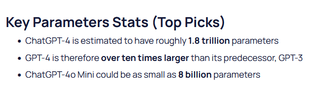

Curiosidade: O ChatGPT-4 possui 1.8 trilhões de parametros de treino, a nossa rede neural possui 62,020.

### Artigos de referencia

## Referencias

[Artigo de detecção de dano com redes neurais](https://www.sciencedirect.com/science/article/pii/S2666827022000433)

Artigo de previsão de sinistros

[Artigo - como o uso de machine learning tem revolucionado o setor de seguros](https://nordica.net.br/hubfs/Nordica_Oct2022/pdf/insurance-overview-portugus-v1.0-final.pdf?hsLang=en)

[Artigo de detecção de danos com redes neurais e datasets para treino de IAs proprias](https://wires.onlinelibrary.wiley.com/doi/epdf/10.1002/widm.70027)

[Pesquisa e Dataset de detecção automática de danos](https://www.kaggle.com/datasets/hendrichscullen/vehide-dataset-automatic-vehicle-damage-detection/data)

[Rede Neural Playground](https://raj-neelam.github.io/Neural-network-Visualizer/)